# Obligatorio Taller de Aprendizaje Automatico

Adrian Arredondo, Alfredo Rodriguez, Federico Ramis

Julio 2021

# LIBRERIAS

```r
if(!require(tidyverse)) {install.packages("tidyverse")}
if(!require(readxl)) {install.packages("readxl")}
if(!require(date)) {install.packages("date")}
if(!require(corrplot)) {install.packages("corrplot")}
if(!require(factoextra)) {install.packages("factoextra")}
if(!require(cluster)) {install.packages("cluster")}
if(!require(amap)) {install.packages("amap")}
if(!require(ggplot2)) {install.packages("ggplot2")}
if(!require(dplyr)) {install.packages("dplyr")}
if(!require(reshape2)) {install.packages("reshape2")}
if(!require(reshape2)) {install.packages("openxlsx")}

library(lattice)
library(tidyverse)
library(readxl)
library(date)
library(corrplot)
library(factoextra)
library(cluster)
library(amap)
library(ggplot2)
library(dplyr)
library(reshape2)
library(openxlsx)

library(lubridate)
memory.limit(size=200000)
```

```
## [1] 2e+05
```

# IMPORTACION

```r
# Importación de la base de datos

datos_pre = read.csv("datos_caso_PEYA.csv", sep = ";")
capacity = read.csv("datos_capacity_PEYA.csv", sep = ";")

# Se agrega el dato de capacity_check
datos <- merge(datos_pre, capacity, by = intersect(names(datos_pre), names(capacity)), all = TRUE)
```

# EXPLORACION y ANALISIS DESCRIPTIVO DE LOS DATOS

Cambio de tipo de dato de algunas de las variables del Data Set para su correcto procesamiento.

## Nuevas variables y transformaciones.

```r
# Se transforma la variable first_date_online en una variable de tipo fecha
datos$first_date_online <- dmy(datos$first_date_online) # puede usarse también la funcion "dmy"

# Se transforma la variable response_time_minute en una variable de tipo númerico
datos$response_time_minute <- as.numeric(gsub(",", ".", datos$response_time_minute))

datos$business_type_name <- as.factor(datos$business_type_name)
datos$delivery_time <- as.factor(datos$delivery_time)
datos$accepts_vouchers <- as.factor(datos$accepts_vouchers)
datos$has_shipping_amount <- as.factor(datos$has_shipping_amount)
datos$has_online_payment <- as.factor(datos$has_online_payment)


datos$is_logistic <- as.character(datos$is_logistic)
datos$capacity_check <- as.character(datos$capacity_check)

# se obtienen los meses trabajados
meses <- as.numeric(format(as.Date(datos$first_date_online), "%Y"))*12 +
  as.numeric(format(as.Date(datos$first_date_online), "%m"))

# Período de estudio: desde Noviembre 2020 a Abril 2021
#Fin del periodo a analizar. Se toma Mayo como el ultimo mes para que en la resta no de cero cuando un partner se afilia en abril 2021
fin<- 2021 * 12 +5

datos$meses = fin - meses
datos$antiguedad <- fin - meses

# Los partners que tienen ingreso anterior a noviembre 2020, todos tienen maximo 6 meses.
datos$meses[datos$first_date_online<='2020-11-01']= 6

# Ahora se hace lo mismo pero para días.
datos$dias = ymd('2021-04-30') - datos$first_date_online
datos$dias[datos$first_date_online<='2020-11-01']= ymd('2021-04-30') - ymd('2020-11-01')

datos$dias = as.numeric(datos$dias)
```

## Universo primario de analisis

Se analiza la distribucion de los partners en funcion del tipo de negocio para tomar la definicion de cuales se tomarán dentro de la vertical Groceries.

```r
# Se analiza la distribucion de partners por tipo de negocio.

# Cantidad de Partners
cantidad_partners<- datos %>%
group_by(datos$business_type_name) %>%
count()
cantidad_partners
```

```
## # A tibble: 7 x 2
## # Groups:   datos$business_type_name [7]
##   `datos$business_type_name`     n
##   <fct>                      <int>
## 1 Coffee                      2968
## 2 Drinks                      1475
## 3 Kiosks                      1637
## 4 Market                      2263
## 5 Pharmacy                     203
## 6 Restaurant                 32756
## 7 Shop                         550
```

```r
# Cantidad total de ordenes por tipo de negocio
cantidad_ordenes_negocio<- datos %>%
group_by(datos$business_type_name) %>%
summarise(ordenes=sum(qty_orders))
cantidad_ordenes_negocio
```

```
## # A tibble: 7 x 2
##   `datos$business_type_name`   ordenes
##   <fct>                          <int>
## 1 Coffee                       8906414
## 2 Drinks                       2188897
## 3 Kiosks                       4821713
## 4 Market                       6143105
## 5 Pharmacy                      316160
## 6 Restaurant                 118264549
## 7 Shop                          125918
```

```r
# Cantidad promedio de ordenes por tipo de negocio
prom_ordenes_negocio<- datos %>%
group_by(datos$business_type_name) %>%
summarise(prom_ordenes=mean(qty_orders))
prom_ordenes_negocio
```

```
## # A tibble: 7 x 2
##   `datos$business_type_name` prom_ordenes
##   <fct>                             <dbl>
## 1 Coffee                            3001.
## 2 Drinks                            1484.
## 3 Kiosks                            2945.
## 4 Market                            2715.
## 5 Pharmacy                          1557.
## 6 Restaurant                        3610.
## 7 Shop                               229.
```

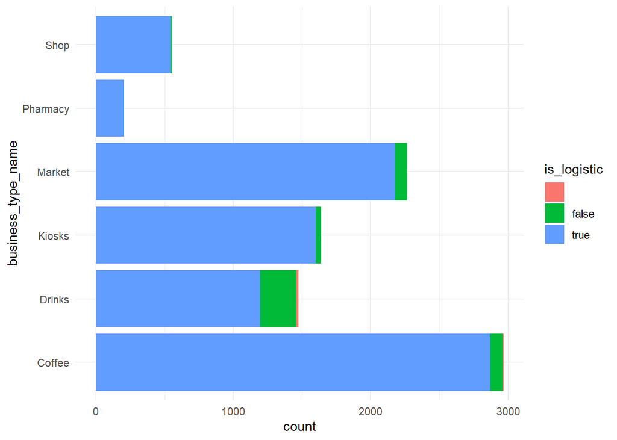

```r
# gráfico de distribución de partners por tipo de negocio y por tipo de entrega.En el gráfico siguiente, se observa gráficamente la distribución de los parnters por tipo de negocio y si tienen delivery a cargo de PeYA (se quita Restaurant para que se pueda observar mejor la comparativa).
datos_sin_rest = datos %>% filter((datos$business_type_name!='Restaurant'))
ggplot(datos_sin_rest, aes(x = business_type_name , fill = is_logistic))+
geom_bar(stat = "count" , position = "stack") +
coord_flip() +
theme_minimal()
```

Se observa que Market y Kiosks tienen un promedio de ordenes similiares para los parnters de estas categorias. Por otro lado, el porcentaje de los partners que cuentan con logistica de envío de PeYa son similares para ambos tipos de negocio. Se entiende que en el caso de Drinks, Pharmacy, Restaurant y Coffee son negocios que desde el punto de vista de los productos que ofrecen, la frecuencia de compra, y la premura en la entrega de los mismos no entran dentro de la categoría de Groceries. Por tanto para el segmento Groceries, se tomarán solamente estas dos categorías de partners.

```r
#Criterio por tipo de negocio
datos_orig = datos
datos<- datos %>% filter((datos$business_type_name=='Market' | datos$business_type_name=='Kiosks'))
```

Se analizan los partners segun su antiguedad para entender si es necesario acotar el universo de análisis. A priori, funcionalmente, no parece lógico considerar un proveedor cuya fecha de ingreso a la plataforma se realiza durante la ventana de análisis. Pero tomando en cuenta que el subconjunto de Market y Kiosks tuvo un crecimiento muy rápido en este período, y para no perder muchos datos, se tomarán en cuenta aquellos partners que ingresaron tres meses antes del fin del período a analizar. Se considera que aquellos partners con una antiguedad menor a los 3 meses, tendrán muchos datos que no serán comparables con aquellos de mayor antiguedad.

```r
# Seleccion por antiguedad.
datos<- datos %>% filter(datos$dias>90)
```